# Assignment 12

Nathan W. Van Bibber

4/11/2020

# Markdown

Markdown is a text-to-HTML tool for web writers.

- Allows you to write in plain text format that is easy to read and write
- then converts to srtucturally valid XHTML (or HTML)

It is a simplified version of a “markup” language that allows the writer to focus on writing and not formatting. It is then easily converted into HTML and other formats

*This text is in Italics*  
**this text is Bold**  
This text is crossed out

- list item 1
- list item 2

## Insert links with format “[Text](url)”

[My GitHub](https://github.com/vanbibn/IntroR-course)  
[My Blog](https://r-youready.blogspot.com/2020/04/assignment-12.html)

### Alternatively, for a more readable format links can be done like this:

###### Note: I’m not sure if this is still a valid way to do hyperlinks… or I’m just doing it wrong.

This format makes your document cleaner and easier to read.

## New lines require a double space at the end of a line

Is this text all - on one line?

This text sould be  
On 2 lines!

# R Markdown

R Mrakdown allows for integration of R code

- R code is evalusted as part of the processing of the markdown
- Results from R code are also inserted into the document

## In line Text computations

The current time is Sat Apr 11, 2020 11:37:21 PM.  
My favorite random number is 0.3896945.

### Incorporate graphics

First I need to simulate data.

```r
x <- rnorm(100)
y <- x + rnorm(100, sd = 0.5)
```

Then I can create a scatterplot of the data.

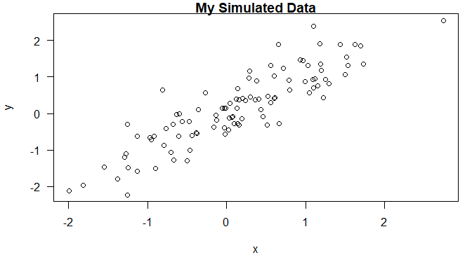

```r
par(mar = c(5,4,1,1), las = 1)
plot(x, y, main = "My Simulated Data")
```